# ALY6000 Module 6 Project

*Name:* Keerthika Kanagaraj  
*Class Name:* ALY6000 Introduction to Analytics  
*Instructor’s Name:* Dr. Dee Chiluiza, PhD  
*Date of submission:* October 26, 2024

**Introduction:** This project involves analyzing a dataset related to Sales of products in the year of 2020. When it comes to retail business or any kind of business, Sales plays a major role in deciding the business growth. Analytics help businesses make informed decisions by analyzing various parameters. Analytics has been used in various domains of retail including supply chain, inventory, manufacturing, marketing, fraud detection etc. Our project focuses on Sales performance with metrics like Market, Region, Segment, Division, Date, Shipping mode, Order priority and performance metrics like product price, shipping cost, quantity ordered, returned quantity, loss per return. There are various questions that can be answered with these metrics including sales across months, profit across markets, Top 5 or Top 10 best performing products with high sales and profit, Ship mode that is preferred in each region and the cost corresponding to it, Returns across countries and which product has been returned the most etc.

Descriptive statistics involve collecting, organizing, summarizing and presenting the data (Bluman,2023). Descriptive Statistics is interpreted using measures of average, measures of variation and measures of position. It has been used in businesses for customer segmentation, sales performance, market trends etc.

Generalizing from samples to populations, estimating and testing hypotheses, identifying correlations between variables, and formulating predictions are all components of inferential statistics (Bluman,2023). Inferential statistics uses probability. It is being used in sales forecasting, market research, quality control with the help of regression analysis, hypothesis testing, sampling, confidence intervals etc.

R script is used for writing and executing code or any data related task where report is not needed. On the other hand R Markdown can contain code, analysis and text in a document format that can be shared and reproduced. R script is ideal for data analysis, building models etc, while R Markdown is ideal for creating detailed reports.

**Analysis:**  
**Task1: Descriptive Summary of the given sales dataset**

**Task description:** This task will be helpful to capture the essence of the dataset using glimpse() and give information about the row count and column count along with column datatypes. A table is used to present the mean, median, standard deviation, minimum value, maximum value, range and quantiles of numerical columns.

```r
sales_df = as.data.frame(sales)
glimpse(sales_df)
```

```
## Rows: 1,000
## Columns: 17
## $ OrderDate          <dttm> 2020-05-08, 2020-09-04, 2020-01-25, 2020-08-19, 20…
## $ ProductID          <chr> "TEC75553", "TEC65040", "TEC70686", "TEC62593", "OF…
## $ City               <chr> "Yaounde", "Pretoria", "Kikwit", "Cape Town", "Ibad…
## $ State              <chr> "Centre", "Gauteng", "Bandundu", "Western Cape", "O…
## $ Country            <chr> "Cameroon", "South Africa", "Democratic Republic of…
## $ Region             <chr> "Central Africa", "Southern Africa", "Central Afric…
## $ Market             <chr> "Africa", "Africa", "Africa", "Africa", "Africa", "…
## $ Segment            <chr> "Home Office", "Corporate", "Consumer", "Corporate"…
## $ Department         <chr> "Technology", "Technology", "Technology", "Technolo…
## $ Division           <chr> "Accessories", "Copiers", "Machines", "Phones", "Ap…
## $ OrderPriority      <chr> "High", "High", "Medium", "High", "Critical", "Crit…
## $ ShipMode           <chr> "First Class", "First Class", "First Class", "First…
## $ Product_Price      <dbl> 360.04, 407.63, 415.82, 288.35, 334.33, 255.87, 322…
## $ Quantity           <dbl> 154, 102, 173, 97, 339, 238, 320, 34, 91, 292, 108,…
## $ Shipping_Cost_Each <dbl> 50.84, 52.50, 53.96, 45.87, 47.00, 49.18, 49.43, 49…
## $ Returns            <dbl> 46, 31, 52, 29, 102, 71, 96, 10, 27, 88, 32, 40, 10…
## $ Loss_Per_Return    <dbl> 126.01, 142.67, 145.54, 100.92, 117.02, 89.55, 112.…
```

```r
mn_product_price = mean(sales_df$Product_Price)
mn_quantity = mean(sales_df$Quantity)
mn_shipping_cost = mean(sales_df$Shipping_Cost_Each)
mn_returns = mean(sales_df$Returns)
mn_loss = mean(sales_df$Loss_Per_Return)

med_product_price = median(sales_df$Product_Price)
med_quantity = median(sales_df$Quantity)
med_shipping_cost = median(sales_df$Shipping_Cost_Each)
med_returns = median(sales_df$Returns)
med_loss = median(sales_df$Loss_Per_Return)

stdev_product_price = sd(sales_df$Product_Price)
stdev_quantity = sd(sales_df$Quantity)
stdev_shipping_cost = sd(sales_df$Shipping_Cost_Each)
stdev_returns = sd(sales_df$Returns)
stdev_loss = sd(sales_df$Loss_Per_Return)

minx_product_price = min(sales_df$Product_Price)
minx_quantity = min(sales_df$Quantity)
minx_shipping_cost = min(sales_df$Shipping_Cost_Each)
minx_returns = min(sales_df$Returns)
minx_loss = min(sales_df$Loss_Per_Return)

maxx_product_price = max(sales_df$Product_Price)
maxx_quantity = max(sales_df$Quantity)
maxx_shipping_cost = max(sales_df$Shipping_Cost_Each)
maxx_returns = max(sales_df$Returns)
maxx_loss = max(sales_df$Loss_Per_Return)

Rng_product_price = maxx_product_price - minx_product_price
Rng_quantity = maxx_quantity - minx_quantity
Rng_shipping_cost = maxx_shipping_cost - minx_shipping_cost
Rng_returns = maxx_returns - minx_returns
Rng_loss = maxx_loss - minx_loss

twenty_fifth_q_product_price = quantile(sales$Product_Price,0.25)
twenty_fifth_q_quantity = quantile(sales_df$Quantity,0.25)
twenty_fifth_q_shipping_cost = quantile(sales_df$Shipping_Cost_Each,0.25)
twenty_fifth_q_returns = quantile(sales_df$Returns,0.25)
twenty_fifth_q_loss = quantile(sales_df$Loss_Per_Return,0.25)

seventy_fifth_q_product_price = quantile(sales$Product_Price,0.75)
seventy_fifth_q_quantity = quantile(sales_df$Quantity,0.75)
seventy_fifth_q_shipping_cost = quantile(sales_df$Shipping_Cost_Each,0.75)
seventy_fifth_q_returns = quantile(sales_df$Returns,0.75)
seventy_fifth_q_loss = quantile(sales_df$Loss_Per_Return,0.75)

# Using vectors to store and organize objects
prod_price_v = c(minx_product_price, maxx_product_price, Rng_product_price, mn_product_price, med_product_price, stdev_product_price,  twenty_fifth_q_product_price, seventy_fifth_q_product_price)
quantity_v = c(minx_quantity, maxx_quantity, Rng_quantity,  mn_quantity, med_quantity, stdev_quantity, twenty_fifth_q_quantity, seventy_fifth_q_quantity)
shipping_cost_v = c(minx_shipping_cost, maxx_shipping_cost, Rng_shipping_cost, mn_shipping_cost, med_shipping_cost, stdev_shipping_cost,  twenty_fifth_q_quantity, seventy_fifth_q_quantity)
returns_v = c(minx_returns, maxx_returns,  Rng_returns,mn_returns, med_returns, stdev_returns,   twenty_fifth_q_returns, seventy_fifth_q_returns)
loss_v = c(minx_loss, maxx_loss, Rng_loss, mn_loss, med_loss, stdev_loss,  twenty_fifth_q_loss, seventy_fifth_q_loss)
column_v = c("Product Price","Quantity","Shipping Cost","Returns","Loss Per Return")
row_v = c("Min","Max","Range","Mean","Median","SD","25th Quantile","75th Quantile")

# Presenting the values using a table
var1 = c(prod_price_v, quantity_v, shipping_cost_v, returns_v, loss_v)
table_var1 = matrix(var1, nrow =8, byrow = F)
colnames(table_var1) = column_v
rownames(table_var1) = row_v
knitr::kable(round(table_var1,2), "html", col.names =  c("Product Price","Quantity","Shipping Cost","Returns","Loss Per Return"), caption = "Descriptive Summary of Sales for the year 2020") %>%
  kable_styling(bootstrap_options = "bordered", full_width = FALSE, position = "left")
```

Descriptive Summary of Sales for the year 2020

[output not shown]

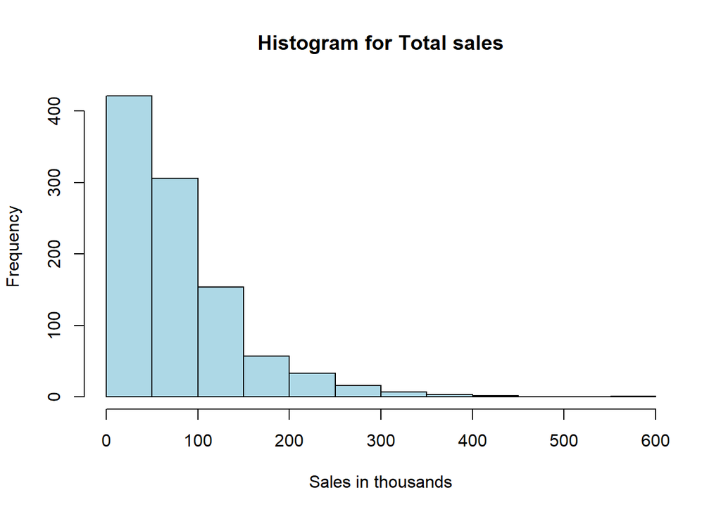

```r
sales_df <- sales_df %>%
  mutate(Sales = sales_df$Product_Price * sales_df$Quantity)

# Histogram
mean_sales = mean(sales_df$Sales)

hist(sales_df$Sales, main = "Histogram for Total sales", col = "lightblue", xlab = "Sales in thousands", ylab = "Frequency", xaxt = "n")
axis(1, at = axTicks(1), labels = axTicks(1) / 1000)
```

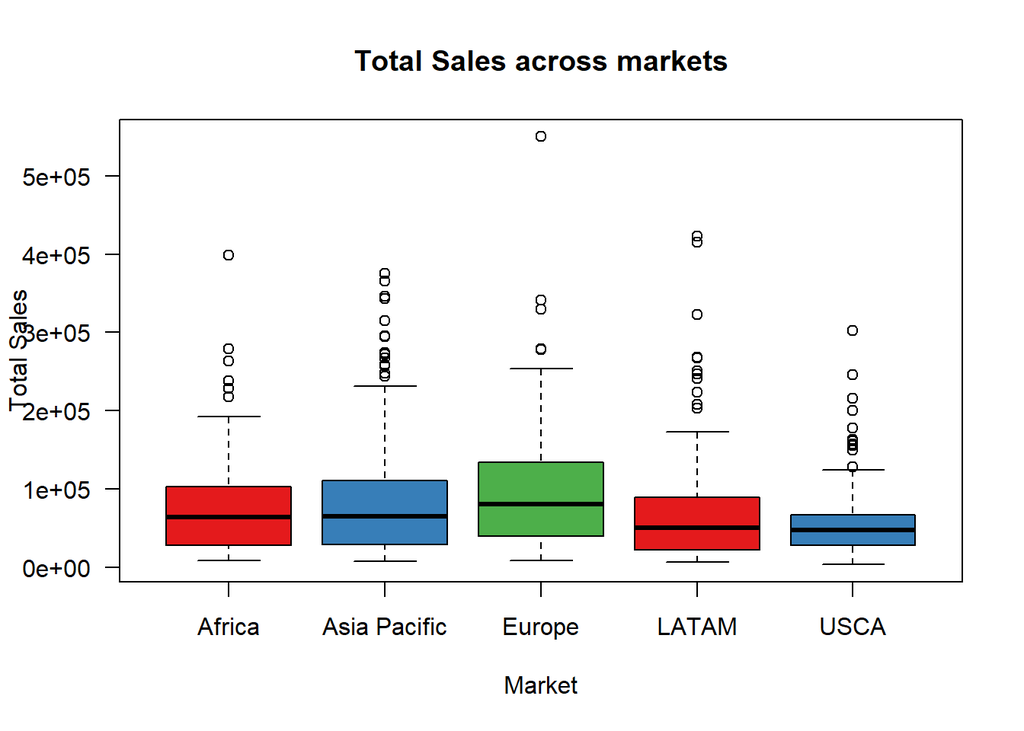

```r
# Box Plot
boxplot(sales_df$Sales ~ sales_df$Market, las=1, col = brewer.pal(3, "Set1"), boxwex = 0.8, xlab = "Market", ylab = "Total Sales" , main = "Total Sales across markets")
```

**Task2: Histogram and Box plot of Shipping Cost Each variable**

**Task description:** Box plot and Histogram are plotted to depict the distribution of cost of shipping. Mean and Median lines are added.

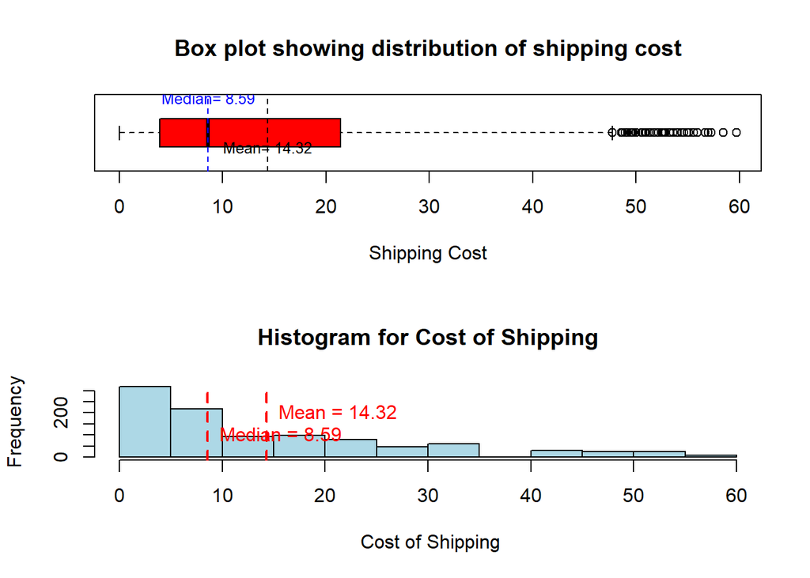

```r
m_ship = mean(sales_df$Shipping_Cost_Each)
med_ship = median(sales_df$Shipping_Cost_Each)
par(mfcol=c(2,1))

boxplot(sales_df$Shipping_Cost_Each, horizontal = TRUE, col = "red", xlab = "Shipping Cost" , main = "Box plot showing distribution of shipping cost")
abline(v = m_ship, col = "black", lwd=1, lty=2)
abline(v = med_ship, col = "blue", lwd=1, lty=2)
text(x = m_ship+0.05, y=0.8, labels = paste("Mean=", round(m_ship,2)), col = "black", cex = 0.8)
text(x = med_ship+0.05, y=1.5, labels = paste("Median=", round(med_ship,2)), col = "blue", cex = 0.8)

hist(sales_df$Shipping_Cost_Each, main = "Histogram for Cost of Shipping", col = "lightblue", xlab = " Cost of Shipping", ylab = "Frequency")
abline(v = m_ship, col = "red", lwd = 2, lty=2)
abline(v = med_ship, col = "red", lwd = 2, lty=2)
text(x = m_ship+0.05, 200, labels = paste("Mean =", round(m_ship, 2)), col = "red", pos = 4)
text(x = med_ship+0.05, 100, labels = paste("Median =", round(med_ship, 2)), col = "red", pos = 4)
```

**Observation:** Box plot shows the distribution of shipping cost. The avg of shipping cost lies at 14.32 which is greater than median of 8.59, which indicates positively skewed distribution. This shows that most of the data points are clustered at the lower end and the presence of higher values pulls the mean upward. Histogram shows that most data points are in the bin of 0 to 5$. Shipping cost imposed on the sales transaction is not high for most of the purchase.

**Task3: Shipping Cost across Markets**

**Task description:** Box Plot is plotted to show the distribution of cost of shipping across various markets

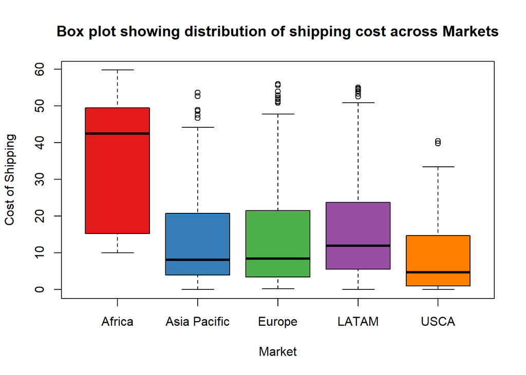

```r
boxplot(sales_df$Shipping_Cost_Each ~ sales_df$Market, col = brewer.pal(5, "Set1"), xlab = "Market" , ylab = "Cost of Shipping", main = "Box plot showing distribution of shipping cost across Markets")
```

**Task 4: Mean and Median Shipping Cost per Market**

**Task description:** In this task, Shipping_Cost_Each variable is grouped by Market and mean and median are calculated. Barplots are then plotted to display mean and median shipping cost per market respectively (Chiluiza D,2022)

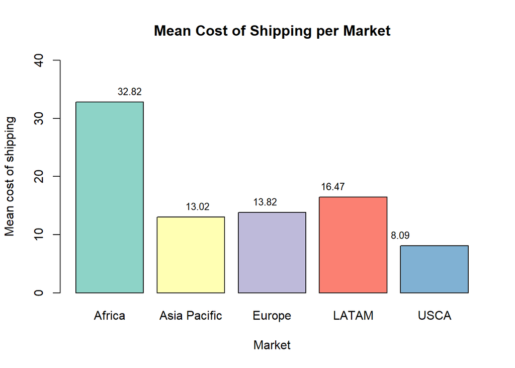

```r
sales_sub = tapply(sales$Shipping_Cost_Each, sales$Market, mean )
bg1 = barplot(sales_sub, xlab = "Market", ylab = "Mean cost of shipping", col = brewer.pal(5, "Set3"), main = "Mean Cost of Shipping per Market", ylim = c(0,40))
text(x=1:length(sales_sub), y= sales_sub, labels = round(sales_sub,2) , cex=0.8, pos=3, col ="black" )
```

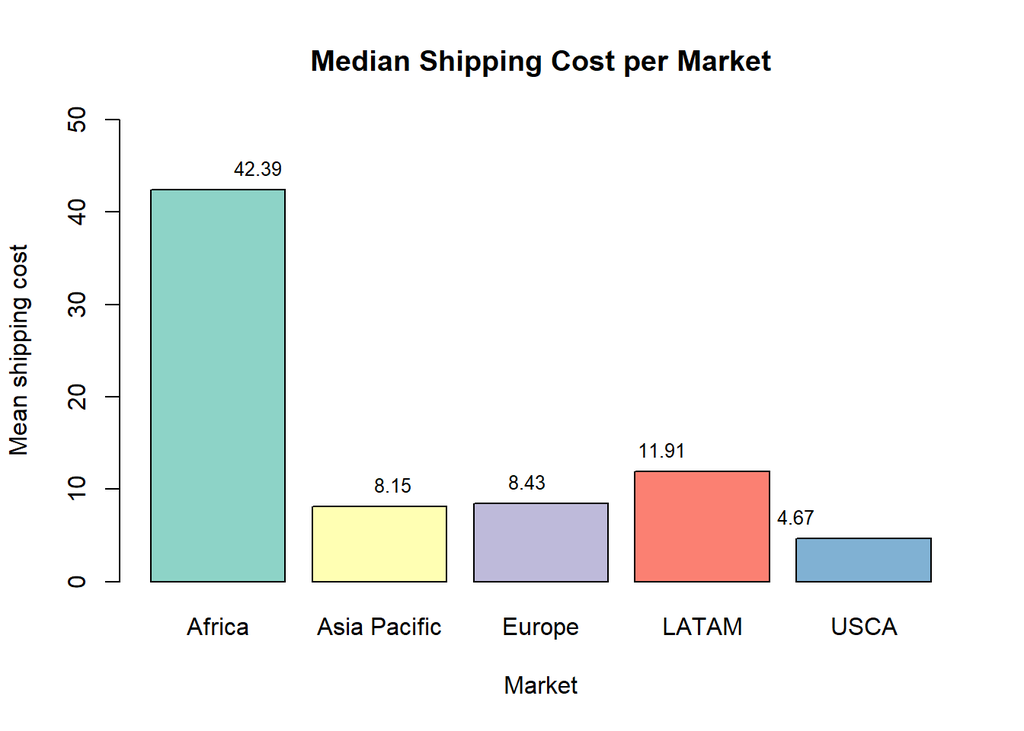

```r
sales_sub2 = tapply(sales$Shipping_Cost_Each, sales$Market, median )
bg2 = barplot(sales_sub2, xlab = "Market", ylab = "Mean shipping cost", col = brewer.pal(5, "Set3"), main = "Median Shipping Cost per Market", ylim = c(0,50))
text(x=1:length(sales_sub2), y= sales_sub2, labels = round(sales_sub2,2) , cex=0.8, pos=3, col ="black" )
```

**Observation:** Africa market has the highest mean for cost of shipping with $32.82. This means shipping cost for every product comes around $33 on average, in Africa. USCA has the lowest mean of shipping cost with $8.09. The median is centered around $42.39 for Africa, still the highest among other markets. Markets like Asia Pacific, Europe and LATAM has lower mean and median values, while USCA being the lowest. Overall, shipping cost is lower in USCA market and higher in Africa.

**Task5: Shipping cost across different shipping modes**

**Task description:** Box plot is used to plot shipping cost against different ship modes.

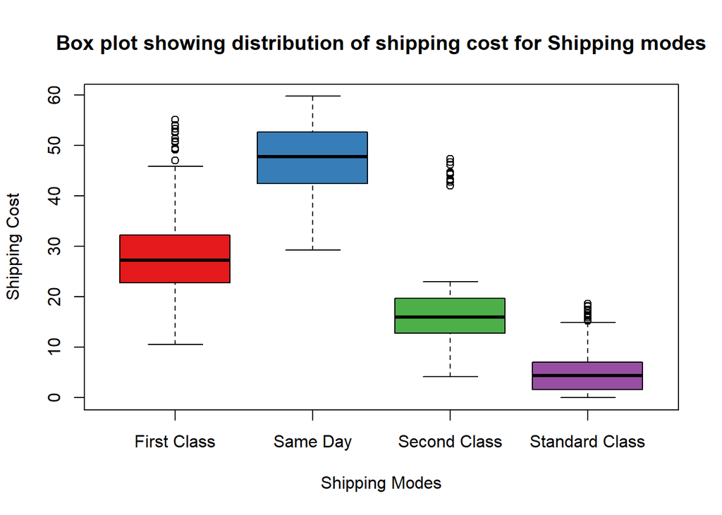

```r
boxplot(sales_df$Shipping_Cost_Each ~ sales_df$ShipMode,  col = brewer.pal(4, "Set1"),xlab = "Shipping Modes", ylab = "Shipping Cost" , main = "Box plot showing distribution of shipping cost for Shipping modes")
```

**Observation:** It is observed that when the shipping is done on the same day, shipping cost is higher compared to any other modes. First class follows next and second class has low shipping cost. Standard shipping has the lowest shipping cost.

**Task6: Calculating derived column ‘Total Sales’ from Product Price and Quantity**

**Task description:** Calculating derived column ‘Total Sales’ from Product Price and Quantity

```r
sales_2 = sales_df %>%
  mutate(Total_Sales = Product_Price*Quantity)
glimpse(sales_2[1,])
```

```
## Rows: 1
## Columns: 19
## $ OrderDate          <dttm> 2020-05-08
## $ ProductID          <chr> "TEC75553"
## $ City               <chr> "Yaounde"
## $ State              <chr> "Centre"
## $ Country            <chr> "Cameroon"
## $ Region             <chr> "Central Africa"
## $ Market             <chr> "Africa"
## $ Segment            <chr> "Home Office"
## $ Department         <chr> "Technology"
## $ Division           <chr> "Accessories"
## $ OrderPriority      <chr> "High"
## $ ShipMode           <chr> "First Class"
## $ Product_Price      <dbl> 360.04
## $ Quantity           <dbl> 154
## $ Shipping_Cost_Each <dbl> 50.84
## $ Returns            <dbl> 46
## $ Loss_Per_Return    <dbl> 126.01
## $ Sales              <dbl> 55446.16
## $ Total_Sales        <dbl> 55446.16
```

**Task7: Summarise the Sales variable by Segment**

**Task description:** Newly created Total Sales column is summarized by Segment

```r
sales_2 %>%
  group_by(Segment) %>%
  summarise(
    sum_of_sales = sum(Total_Sales)
  ) %>%
  kable(align = c("l","c"), table.attr = "style=‘width:42%;'") %>%
  kable_styling(full_width = FALSE ) %>%
  kable_classic_2
```

| Segment | sum_of_sales |
| --- | --- |
| Consumer | 41640653 |
| Corporate | 23377596 |
| Home Office | 12980145 |

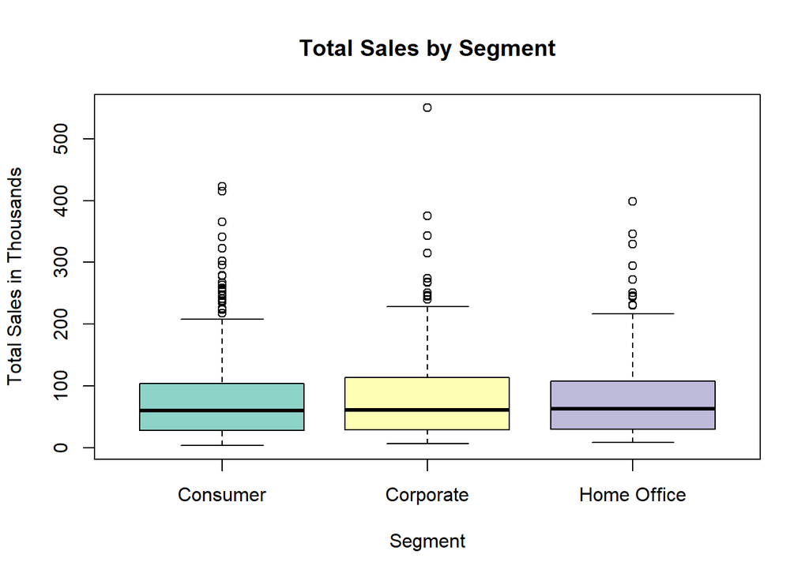

```r
boxplot(sales_2$Total_Sales ~ sales_2$Segment, xlab = "Segment", ylab = "Total Sales in Thousands", col = brewer.pal(3, "Set3"), main = "Total Sales by Segment", yaxt = "n" )
axis(2, at = axTicks(2), labels = axTicks(2) / 1000)
```

**Observation:** From the table it is observed that Consumer Segment made highest sales, Corporate being the second and Home Office being the lowest.

**Task8: Analyzing Africa Market for Profits based on Division**

```r
sales_3 = sales_2 %>%
  mutate(Profit = Total_Sales-(Loss_Per_Return*Quantity)-(Shipping_Cost_Each*Quantity))

Africa_sub = sales_3 %>%
  filter(Market == "Africa")

Profit_summ = Africa_sub %>%
  group_by(Division) %>%
  summarise(
    sum_of_profit = sum(Profit)
  )

Profit_summ %>%
  kable(align = c("l","c"), table.attr = "style=‘width:42%;'") %>%
  kable_styling(full_width = FALSE ) %>%
  kable_classic_2
```

| Division | sum_of_profit |
| --- | --- |
| Accessories | 181508.49 |
| Appliances | 233949.81 |
| Art | 309982.21 |
| Binders | 106297.26 |
| Bookcases | 115031.26 |
| Chairs | 52919.92 |
| Copiers | 313180.54 |
| Furnishings | 21796.22 |
| Machines | 282019.02 |
| Paper | 73808.00 |
| Phones | 268788.85 |
| Storage | 852870.34 |
| Supplies | 152995.63 |
| Tables | 37513.64 |

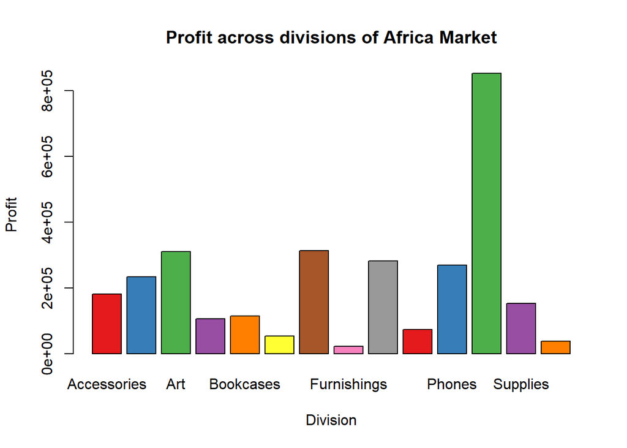

```r
bg_Af = barplot(  height = Profit_summ$sum_of_profit,
  names.arg = Profit_summ$Division, xlab = "Division", ylab = "Profit", col = brewer.pal(14, "Set1"), main = "Profit across divisions of Africa Market")
```

This project helped me how to approach a project and begin my analysis. I got to understand how mutate(), filter() and group_by() can be used together for deep dive analysis. I also gained knowledge on plotting the filtered data using various graphs. I went through the instructions file mutiple times and then started with my tasks. I did my coding first, wrote observations from the results and went back to make sure formatting is done properly. Once all the tasks are complete, I wrote my introduction, conclusion and bibliography.

**Bibliography:**  
1) Panik, Michael J., et al. Advanced Statistics from an Elementary Point of View, Elsevier Science & Technology, 2005. ProQuest Ebook Central, https://ebookcentral.proquest.com/lib/northeastern-ebooks/detail.action?docID=340641.

2. Bluman AG. Elementary Statistics : A Step by Step Approach. Eleventh edition. McGraw Hill LLC; 2023.
3. Chiluiza, D. (n.d.). Boxplots. RPubs. Retrieved [October 26, 2024], from https://rpubs.com/Dee_Chiluiza/boxplots
4. Chiluiza, D. (n.d.). Histograms in R. RPubs. Retrieved [October 26, 2024], from https://rpubs.com/Dee_Chiluiza/816756

**Acknowledgement:**  
Special Thanks to Professor Dee for laying a strong foundation for R. All the knowledge I have gained so far will be extremely helpful throughout my career.